# Homework 1 FInal

Derek Bornath

14/01/2020

##Question 1: Create a new vector in R with the data for each strain.

```r
transgenic.strain.A = c(0.17,0.20,0.13,0.20,0.24,0.25,0.15,0.21,0.21)
transgenic.strain.B = c(0.47,0.21,0.34,0.32,0.33,0.29,0.18,0.20,0.25)
common.strain = c(0.44,0.33,0.37,0.33,0.31,0.27,0.22,0.30,0.28)
```

##Question 2: What is the difference between the means of the two transgenic streams?

```r
mean(transgenic.strain.A)-
mean(transgenic.strain.B)
```

```
## [1] -0.09222222
```

#The difference between the two means of trangenic strains is 0.09222222

##Question 3: What is the difference between the means of the common strain and transgenic strain A

```r
mean(common.strain)-
mean(transgenic.strain.A)
```

```
## [1] 0.1211111
```

#The difference between the means of the common strain and transgenic strain A are 0.1211111

##Question 4: Create a histogram of the hydrogen peroxide concentrations in the common strain

```r
potato.H2O2=read.csv(choose.files())
```

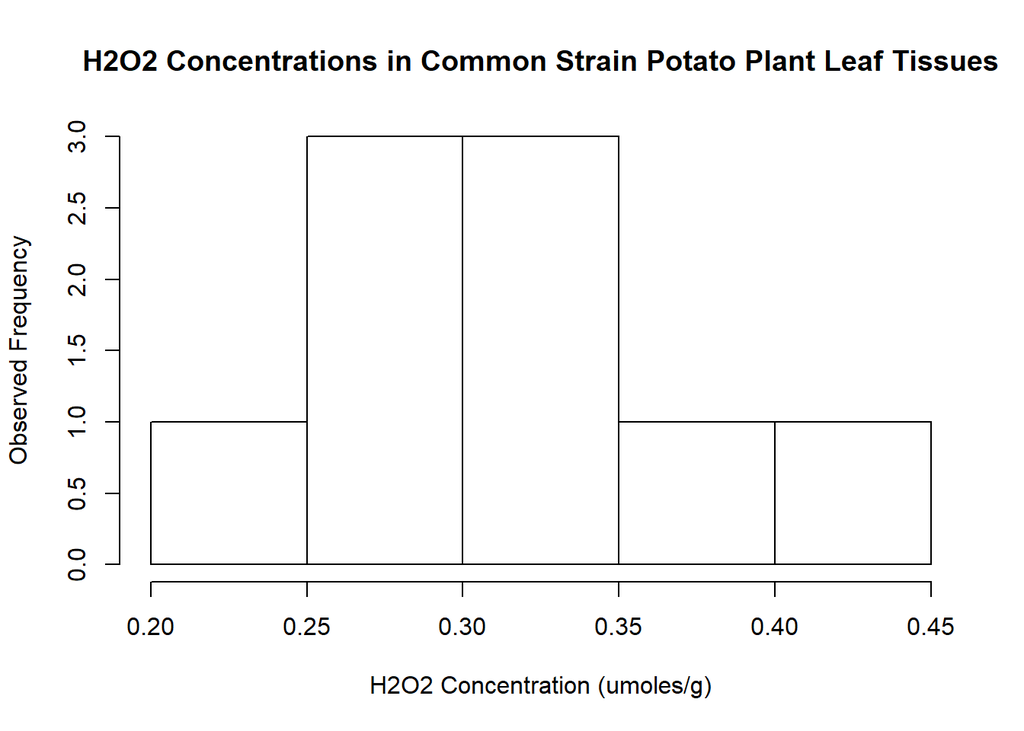

```r
hist(potato.H2O2$Common.Strain, main = "H2O2 Concentrations in Common Strain Potato Plant Leaf Tissues", xlab="H2O2 Concentration (umoles/g)", ylab="Observed Frequency")
```

##Question 5: Enter each column as a vector in R, and collect these into a single data frame. Name the hydrogen peroxide column as ‘Peroxide’ and fungal growth rate column ‘Growth.rate’.

```r
Peroxide=c(0.27,0.21,0.34,0.32,0.24,0.29,0.18,0.20,0.29)
Growth.rate=c(1.79,1.01,1.71,1.89,1.41,1.15,1.13,1.20,1.10)
Sample.number=c(1,2,3,4,5,6,7,8,9)
```

#Collecting the vectors into a data frame

```r
Fungus=data.frame(Peroxide,Growth.rate)
Fungus
```

```
##   Peroxide Growth.rate
## 1     0.27        1.79
## 2     0.21        1.01
## 3     0.34        1.71
## 4     0.32        1.89
## 5     0.24        1.41
## 6     0.29        1.15
## 7     0.18        1.13
## 8     0.20        1.20
## 9     0.29        1.10
```

##Question 6: Create a scatter plot of fungal growth rate versus peroxide concentration from the newly created data frame. Make sure to label the plot properly (label the axes and make sure to provide the measurement units).

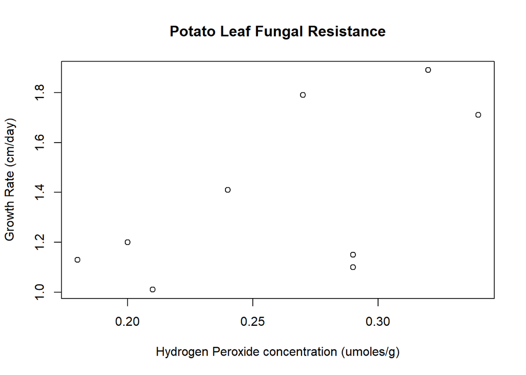

```r
plot(Fungus$Peroxide,Fungus$Growth.rate, xlab='Hydrogen Peroxide concentration (umoles/g)', ylab= 'Growth Rate (cm/day)', main='Potato Leaf Fungal Resistance')
```

##Question 7:How does the growth rate of the fungus change with increasing levels of hydrogen peroxide, and does this agree or disagree with the hypothesis?

```r
mean(Peroxide)
```

```
## [1] 0.26
```

```r
mean(Growth.rate)
```

```
## [1] 1.376667
```

```r
my.reg=lm(Fungus$Growth.rate~Fungus$Peroxide)
summary(my.reg)
```

```
##
## Call:
## lm(formula = Fungus$Growth.rate ~ Fungus$Peroxide)
##
## Residuals:
##      Min       1Q   Median       3Q      Max
## -0.39098 -0.17614  0.05196  0.10954  0.37523
##
## Coefficients:
##                 Estimate Std. Error t value Pr(>|t|)
## (Intercept)       0.3859     0.4682   0.824   0.4370
## Fungus$Peroxide   3.8105     1.7652   2.159   0.0677 .
## ---
## Signif. codes:  0 '***' 0.001 '**' 0.01 '*' 0.05 '.' 0.1 ' ' 1
##
## Residual standard error: 0.278 on 7 degrees of freedom
## Multiple R-squared:  0.3997, Adjusted R-squared:  0.3139
## F-statistic:  4.66 on 1 and 7 DF,  p-value: 0.06774
```

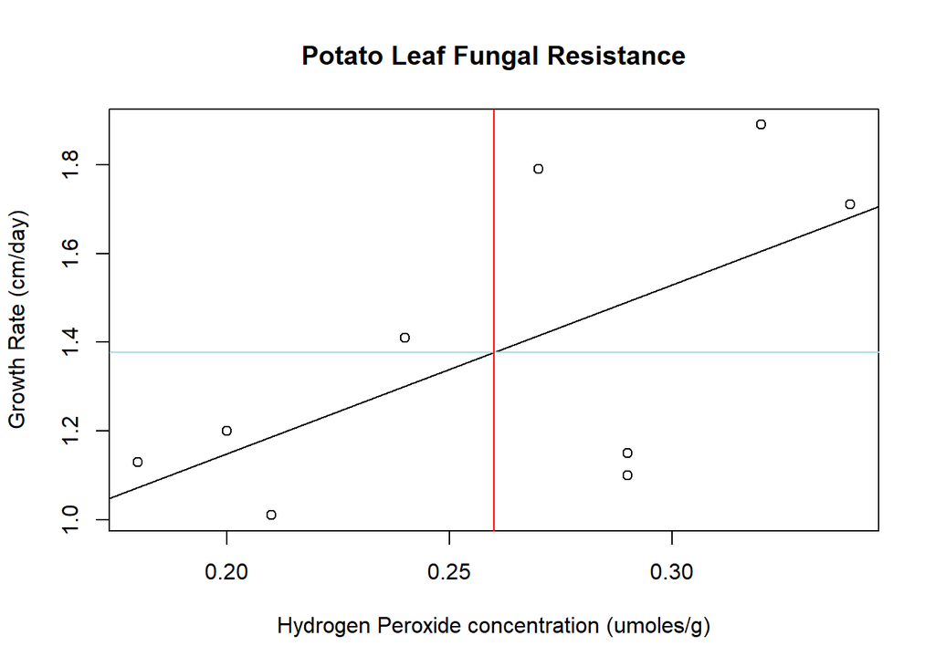

```r
plot(Fungus$Peroxide,Fungus$Growth.rate, xlab='Hydrogen Peroxide concentration (umoles/g)', ylab= 'Growth Rate (cm/day)', main='Potato Leaf Fungal Resistance')
abline(my.reg)
abline(h=1.376667, col='light blue')
abline(v=0.26, col='red')
```

##Question 8: Re-create this table in Excel and save as a comma separated values file. Read the data into R using the read.csv function.

```r
turtle.nesting=read.csv(file.choose())
```

```r
turtle.nesting
```

```
##    Nesting.status      Species
## 1         Success Olive Ridley
## 2         Success Olive Ridley
## 3         Success Olive Ridley
## 4         Success Olive Ridley
## 5         Success Olive Ridley
## 6         Success Olive Ridley
## 7         Success Olive Ridley
## 8         Success Olive Ridley
## 9         Success Olive Ridley
## 10        Success Olive Ridley
## 11        Success Olive Ridley
## 12        Success Olive Ridley
## 13        Success Olive Ridley
## 14        Success Olive Ridley
```

[output cut: 19 more lines]

##Question 9: Use the table function to create a contingency table showing the number of aborted and successful nesting attempts for each species.

```r
my.table=table(turtle.nesting$Nesting.status,turtle.nesting$Species)
my.table
```

```
##
##           Hawksbill Leatherback Olive Ridley
##   Aborted         3           2            4
##   Success         4           4           16
```

##Question 10: Make and label a grouped barplot that represents the nesting patterns for all three turtle species. Colour the bars for successful green and the bars for aborted red. Make sure to label the axes.

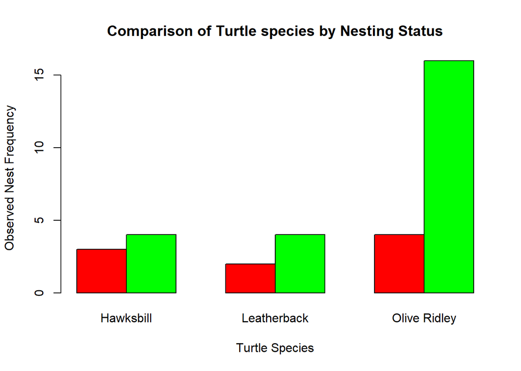

```r
barplot(my.table,main="Comparison of Turtle species by Nesting Status", xlab='Turtle Species', ylab= 'Observed Nest Frequency', col = c('red','green'), beside=TRUE)
```

##Question 11:Determine the mean and standard deviation of successful nesting events among all marine turtles.

```r
nest.survival=c(my.table[2,1],my.table[2,2],my.table[2,3])
nest.survival
```

```
## [1]  4  4 16
```

```r
mean(nest.survival)
```

```
## [1] 8
```

```r
sd(nest.survival)
```

```
## [1] 6.928203
```

#The mean and standard deviation of successful nesting amongst all turtle species are 8 and 6.9, respectively.

##Question 12: Calculate the proportion of failed nesting attempts for each species. Based on this, which species would you choose as needing the greatest conservation effort?

```r
hawksbill.aborted=my.table[1,1]/ (my.table[1,1]+my.table[2,1])
hawksbill.aborted
```

```
## [1] 0.4285714
```

```r
leatherback.aborted=my.table[1,2]/ (my.table[1,2]+my.table[2,2])
leatherback.aborted
```

```
## [1] 0.3333333
```

```r
oliveridley.aborted=my.table[1,3]/ (my.table[1,3]+my.table[2,3])
oliveridley.aborted
```

```
## [1] 0.2
```

#Based on this the Hawksbill species need the greatest conservaton effort as 43% of their nests are failed attempts.

##Question 13: Enter data into Excel and import the file to R.

```r
hatchery.survival=read.csv(choose.files())
hatchery.survival
```

```
##    Nest Olive.Ridley Hawksbill Leatherback
## 1     1          127       143         149
## 2     2          110       144         143
## 3     3          112       124         128
## 4     4          110       145         111
## 5     5          118       122         110
## 6     6          115       132         109
## 7     7          120       121         110
## 8     8          108       127         105
## 9     9          120       151          89
## 10   10          126       105          98
## 11   11          114       141         112
## 12   12          130       132         108
## 13   13          123       145         109
## 14   14          128       132         101
## 15   15          121       151          97
## 16   16          109       111         110
```

##Question 14:Create a boxplot comparing different turtle species and the number of eggs found in the nest. Don’t forget to label your axes.

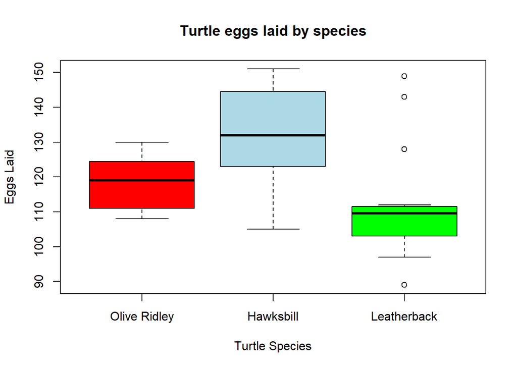

```r
boxplot(hatchery.survival$Olive.Ridley, hatchery.survival$Hawksbill, hatchery.survival$Leatherback, names=c("Olive Ridley", "Hawksbill", "Leatherback"), main= "Turtle eggs laid by species", ylab='Eggs Laid', xlab='Turtle Species', col=c('red', 'light blue','green'))
```

##Question 15: Create a scatter plot of the number of Leatherback turtle eggs (y-axis) against the number of Hawksbill turtle eggs (x-axis) across all beach sections

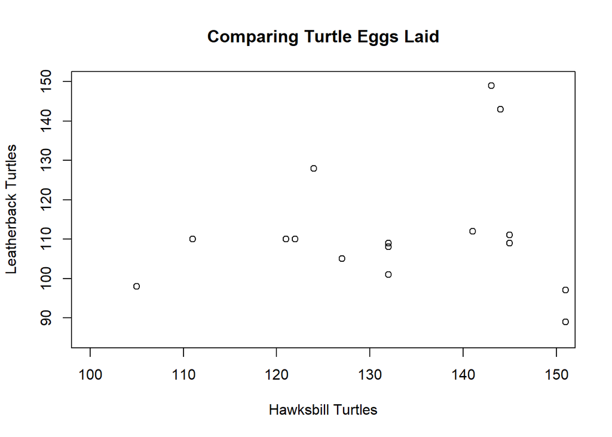

```r
plot(hatchery.survival$Hawksbill, hatchery.survival$Leatherback, main='Comparing Turtle Eggs Laid', xlab='Hawksbill Turtles', ylab='Leatherback Turtles', xlim = c(100,150), ylim=c(85,150))
```